# Lab 6

[GitHub Repository](https://github.com/pinoliar/GSB_544)

```python
import pandas as pd
import numpy as np
from sklearn.pipeline import Pipeline
from sklearn.compose import make_column_selector, ColumnTransformer
from sklearn.preprocessing import StandardScaler, OneHotEncoder, PolynomialFeatures
from sklearn.linear_model import LinearRegression, Ridge, Lasso, ElasticNet
from sklearn.model_selection import train_test_split, GridSearchCV, cross_val_score
from sklearn.metrics import r2_score
df = pd.read_csv("/Users/pinoliara/Downloads/GSB_544/Week_7/Hitters.csv")
```

```python
df.isnull().sum()
df = df.dropna(subset=["Salary"])
df
```

|  | AtBat | Hits | HmRun | Runs | RBI | Walks | Years | CAtBat | CHits | CHmRun | CRuns | CRBI | CWalks | League | Division | PutOuts | Assists | Errors | Salary | NewLeague |
| --- | --- | --- | --- | --- | --- | --- | --- | --- | --- | --- | --- | --- | --- | --- | --- | --- | --- | --- | --- | --- |
| 1 | 315 | 81 | 7 | 24 | 38 | 39 | 14 | 3449 | 835 | 69 | 321 | 414 | 375 | N | W | 632 | 43 | 10 | 475.0 | N |
| 2 | 479 | 130 | 18 | 66 | 72 | 76 | 3 | 1624 | 457 | 63 | 224 | 266 | 263 | A | W | 880 | 82 | 14 | 480.0 | A |
| 3 | 496 | 141 | 20 | 65 | 78 | 37 | 11 | 5628 | 1575 | 225 | 828 | 838 | 354 | N | E | 200 | 11 | 3 | 500.0 | N |
| 4 | 321 | 87 | 10 | 39 | 42 | 30 | 2 | 396 | 101 | 12 | 48 | 46 | 33 | N | E | 805 | 40 | 4 | 91.5 | N |
| 5 | 594 | 169 | 4 | 74 | 51 | 35 | 11 | 4408 | 1133 | 19 | 501 | 336 | 194 | A | W | 282 | 421 | 25 | 750.0 | A |
| ... | ... | ... | ... | ... | ... | ... | ... | ... | ... | ... | ... | ... | ... | ... | ... | ... | ... | ... | ... | ... |
| 317 | 497 | 127 | 7 | 65 | 48 | 37 | 5 | 2703 | 806 | 32 | 379 | 311 | 138 | N | E | 325 | 9 | 3 | 700.0 | N |
| 318 | 492 | 136 | 5 | 76 | 50 | 94 | 12 | 5511 | 1511 | 39 | 897 | 451 | 875 | A | E | 313 | 381 | 20 | 875.0 | A |
| 319 | 475 | 126 | 3 | 61 | 43 | 52 | 6 | 1700 | 433 | 7 | 217 | 93 | 146 | A | W | 37 | 113 | 7 | 385.0 | A |
| 320 | 573 | 144 | 9 | 85 | 60 | 78 | 8 | 3198 | 857 | 97 | 470 | 420 | 332 | A | E | 1314 | 131 | 12 | 960.0 | A |
| 321 | 631 | 170 | 9 | 77 | 44 | 31 | 11 | 4908 | 1457 | 30 | 775 | 357 | 249 | A | W | 408 | 4 | 3 | 1000.0 | A |

263 rows × 20 columns

```python
df.duplicated().sum()
```

```
np.int64(0)
```

Part I: Different Model Specs

A. Regression without regularization

1. Create a pipeline that includes all the columns as predictors for Salary, and performs ordinary linear regression

```python
X = df.drop("Salary", axis=1)
y = df["Salary"]

ct = ColumnTransformer(
    [
        ("dummify",
         OneHotEncoder(sparse_output=False, handle_unknown="ignore"),
         make_column_selector(dtype_include=object)),
        ("standardize",
         StandardScaler(),
         make_column_selector(dtype_include=np.number))
    ],
    remainder="passthrough"
)

lr_pipeline = Pipeline([
    ("preprocessing", ct),
    ("linear_regression", LinearRegression())
])
```

2. Fit this pipeline to the full dataset, and interpret a few of the most important coefficients.

```python
lr_pipeline_fittedI = lr_pipeline.fit(X, y)
lr_pipeline_fittedI["linear_regression"].coef_

feature_names = lr_pipeline_fittedI.named_steps["preprocessing"].get_feature_names_out()
coef_df = pd.DataFrame({
    "feature": feature_names,
    "coefficient": lr_pipeline_fittedI["linear_regression"].coef_,
    "abs_coefficient": np.abs(lr_pipeline_fittedI["linear_regression"].coef_)
}).sort_values("abs_coefficient", ascending=False)
coef_df
```

|  | feature | coefficient | abs_coefficient |
| --- | --- | --- | --- |
| 16 | standardize__CRuns | 480.747135 | 480.747135 |
| 13 | standardize__CAtBat | -391.038655 | 391.038655 |
| 7 | standardize__Hits | 337.830479 | 337.830479 |
| 6 | standardize__AtBat | -291.094556 | 291.094556 |
| 17 | standardize__CRBI | 260.689886 | 260.689886 |
| 18 | standardize__CWalks | -213.892259 | 213.892259 |
| 11 | standardize__Walks | 135.073897 | 135.073897 |
| 14 | standardize__CHits | 86.687617 | 86.687617 |
| 19 | standardize__PutOuts | 78.761296 | 78.761296 |
| 9 | standardize__Runs | -60.572479 | 60.572479 |
| 3 | dummify__Division_W | -58.424623 | 58.424623 |
| 2 | dummify__Division_E | 58.424623 | 58.424623 |
| 20 | standardize__Assists | 53.732490 | 53.732490 |
| 8 | standardize__HmRun | 37.853837 | 37.853837 |
| 1 | dummify__League_N | 31.299712 | 31.299712 |
| 0 | dummify__League_A | -31.299712 | 31.299712 |
| 10 | standardize__RBI | -26.994984 | 26.994984 |
| 21 | standardize__Errors | -22.160862 | 22.160862 |
| 12 | standardize__Years | -16.693359 | 16.693359 |
| 15 | standardize__CHmRun | -14.181723 | 14.181723 |
| 4 | dummify__NewLeague_A | 12.381163 | 12.381163 |
| 5 | dummify__NewLeague_N | -12.381163 | 12.381163 |

3. Use cross-validation to estimate the MSE you would expect if you used this pipeline to predict 1989 salaries.

```python
lr_scoresI = cross_val_score(lr_pipeline, X, y, cv=5, scoring="neg_mean_squared_error")
lr_scoresI.mean()
```

```
np.float64(-121136.31031816886)
```

B. Ridge regression

1. Create a pipeline that includes all the columns as predictors for Salary, and performs ordinary ridge regression

```python
ridge_pipeline = Pipeline([
    ("preprocessing", ct),
    ("ridge_regression", Ridge(alpha=1))
])
```

2. Use cross-validation to tune the λ hyperparameter.

```python
ridge_pipeline = Pipeline(
  [("preprocessing", ct),
  ("ridge_regression", Ridge())]
).set_output(transform="pandas")

alphas = {"ridge_regression__alpha": np.array([100, 10, 1, 0.1, 0.01])}

gscv = GridSearchCV(ridge_pipeline, param_grid=alphas, cv = 5, scoring="neg_mean_squared_error")

gscv_fitted_ridgeI = gscv.fit(X, y)
```

3. Fit the pipeline with your chosen λ to the full dataset, and interpret a few of the most important coefficients.

```python
ridge_pipeline = Pipeline(
  [("preprocessing", ct),
  ("ridge_regression", Ridge(alpha=gscv_fitted_ridgeI.best_params_["ridge_regression__alpha"]))]
  )
ridge_pipeline_fittedI = ridge_pipeline.fit(X, y)
ridge_pipeline_fittedI["ridge_regression"].coef_

feature_names = ridge_pipeline_fittedI.named_steps["preprocessing"].get_feature_names_out()
coef_df = pd.DataFrame({
    "feature": feature_names,
    "coefficient": ridge_pipeline_fittedI["ridge_regression"].coef_,
    "abs_coefficient": np.abs(ridge_pipeline_fittedI["ridge_regression"].coef_)
}).sort_values("abs_coefficient", ascending=False)
coef_df
```

|  | feature | coefficient | abs_coefficient |
| --- | --- | --- | --- |
| 16 | standardize__CRuns | 320.412169 | 320.412169 |
| 7 | standardize__Hits | 296.645050 | 296.645050 |
| 6 | standardize__AtBat | -270.686441 | 270.686441 |
| 13 | standardize__CAtBat | -225.406548 | 225.406548 |
| 18 | standardize__CWalks | -184.423611 | 184.423611 |
| 17 | standardize__CRBI | 160.386784 | 160.386784 |
| 14 | standardize__CHits | 126.659607 | 126.659607 |
| 11 | standardize__Walks | 124.407173 | 124.407173 |
| 19 | standardize__PutOuts | 78.623656 | 78.623656 |
| 3 | dummify__Division_W | -60.015595 | 60.015595 |
| 2 | dummify__Division_E | 60.015595 | 60.015595 |
| 20 | standardize__Assists | 47.462597 | 47.462597 |
| 15 | standardize__CHmRun | 39.070924 | 39.070924 |
| 12 | standardize__Years | -38.667748 | 38.667748 |
| 1 | dummify__League_N | 30.438855 | 30.438855 |
| 0 | dummify__League_A | -30.438855 | 30.438855 |
| 9 | standardize__Runs | -29.339406 | 29.339406 |
| 21 | standardize__Errors | -23.724190 | 23.724190 |
| 8 | standardize__HmRun | 18.100592 | 18.100592 |
| 4 | dummify__NewLeague_A | 13.111282 | 13.111282 |
| 5 | dummify__NewLeague_N | -13.111282 | 13.111282 |
| 10 | standardize__RBI | -9.113295 | 9.113295 |

4. Report the MSE you would expect if you used this pipeline to predict 1989 salaries.

```python
ridge_scoresI = cross_val_score(ridge_pipeline, X, y, cv=5, scoring="neg_mean_squared_error")
ridge_scoresI.mean()
```

```
np.float64(-119144.43267691587)
```

C. Lasso Regression

1. Create a pipeline that includes all the columns as predictors for Salary, and performs ordinary ridge regression

```python
lasso_pipeline = Pipeline(
  [("preprocessing", ct),
  ("lasso_regression", Lasso(alpha=1))]
)
```

2. Use cross-validation to tune the λ hyperparameter.

```python
lasso_pipeline = Pipeline(
  [("preprocessing", ct),
  ("lasso_regression", Lasso())]
).set_output(transform="pandas")

alphas = {"lasso_regression__alpha": np.array([100, 10, 1, 0.1, 0.01])}

gscv = GridSearchCV(lasso_pipeline, param_grid=alphas, cv = 5, scoring="neg_mean_squared_error")

gscv_fitted_lassoI = gscv.fit(X, y)
```

3. Fit the pipeline with your chosen λ to the full dataset, and interpret a few of the most important coefficients.

```python
lasso_pipeline = Pipeline(
  [("preprocessing", ct),
  ("lasso_regression", Lasso(alpha=gscv_fitted_lassoI.best_params_["lasso_regression__alpha"]))]
)
lasso_pipeline_fittedI = lasso_pipeline.fit(X, y)
lasso_pipeline_fittedI["lasso_regression"].coef_

feature_names = lasso_pipeline_fittedI.named_steps["preprocessing"].get_feature_names_out()
coef_df = pd.DataFrame({
    "feature": feature_names,
    "coefficient": lasso_pipeline_fittedI["lasso_regression"].coef_,
    "abs_coefficient": np.abs(lasso_pipeline_fittedI["lasso_regression"].coef_)
}).sort_values("abs_coefficient", ascending=False)
coef_df
```

|  | feature | coefficient | abs_coefficient |
| --- | --- | --- | --- |
| 16 | standardize__CRuns | 3.755655e+02 | 3.755655e+02 |
| 7 | standardize__Hits | 3.043595e+02 | 3.043595e+02 |
| 6 | standardize__AtBat | -2.823710e+02 | 2.823710e+02 |
| 17 | standardize__CRBI | 1.926109e+02 | 1.926109e+02 |
| 18 | standardize__CWalks | -1.896446e+02 | 1.896446e+02 |
| 13 | standardize__CAtBat | -1.626398e+02 | 1.626398e+02 |
| 11 | standardize__Walks | 1.206953e+02 | 1.206953e+02 |
| 2 | dummify__Division_E | 1.144130e+02 | 1.144130e+02 |
| 19 | standardize__PutOuts | 7.876037e+01 | 7.876037e+01 |
| 20 | standardize__Assists | 4.199668e+01 | 4.199668e+01 |
| 0 | dummify__League_A | -3.582607e+01 | 3.582607e+01 |
| 12 | standardize__Years | -3.494815e+01 | 3.494815e+01 |
| 9 | standardize__Runs | -2.496651e+01 | 2.496651e+01 |
| 21 | standardize__Errors | -1.847938e+01 | 1.847938e+01 |
| 15 | standardize__CHmRun | 1.422599e+01 | 1.422599e+01 |
| 8 | standardize__HmRun | 1.112702e+01 | 1.112702e+01 |
| 3 | dummify__Division_W | -2.036898e-11 | 2.036898e-11 |
| 1 | dummify__League_N | 1.214304e-14 | 1.214304e-14 |
| 10 | standardize__RBI | -0.000000e+00 | 0.000000e+00 |
| 14 | standardize__CHits | 0.000000e+00 | 0.000000e+00 |
| 5 | dummify__NewLeague_N | -0.000000e+00 | 0.000000e+00 |
| 4 | dummify__NewLeague_A | 0.000000e+00 | 0.000000e+00 |

4. Report the MSE you would expect if you used this pipeline to predict 1989 salaries.

```python
lasso_scoresI = cross_val_score(lasso_pipeline, X, y, cv=5, scoring="neg_mean_squared_error")
lasso_scoresI.mean()
```

```
np.float64(-119761.58740741308)
```

D. Elastic Net

1. Create a pipeline that includes all the columns as predictors for Salary, and performs ordinary ridge regression

```python
elastic_pipeline = Pipeline(
  [("preprocessing", ct),
  ("elastic_net", ElasticNet(alpha=1, l1_ratio=0.5))]
)
```

2. Use cross-validation to tune the λ and α hyperparameter.

```python
param_grid = {
  "elastic_net__alpha": [1, 10, 100],
  "elastic_net__l1_ratio": np.arange(0.0, 1.2, 0.2),
  }

gscv_elastic = GridSearchCV(elastic_pipeline, param_grid = param_grid, cv = 5, scoring = "neg_mean_squared_error")

elastic_pipeline_fitted = gscv_elastic.fit(X, y)
```

3. Fit the pipeline with your chosen hyperparameters to the full dataset, and interpret a few of the most important coefficients.

```python
elastic_pipeline = Pipeline(
  [("preprocessing", ct),
  ("elastic_net", ElasticNet(alpha = elastic_pipeline_fitted.best_params_["elastic_net__alpha"], l1_ratio = elastic_pipeline_fitted.best_params_["elastic_net__l1_ratio"]))]
  )
elastic_pipeline_fittedI = elastic_pipeline.fit(X, y)
elastic_pipeline_fittedI["elastic_net"].coef_
feature_names = elastic_pipeline_fittedI.named_steps["preprocessing"].get_feature_names_out()
coef_df = pd.DataFrame({
    "feature": feature_names,
    "coefficient": elastic_pipeline_fittedI["elastic_net"].coef_,
    "abs_coefficient": np.abs(elastic_pipeline_fittedI["elastic_net"].coef_)
}).sort_values("abs_coefficient", ascending=False)
coef_df
```

|  | feature | coefficient | abs_coefficient |
| --- | --- | --- | --- |
| 16 | standardize__CRuns | 3.755655e+02 | 3.755655e+02 |
| 7 | standardize__Hits | 3.043595e+02 | 3.043595e+02 |
| 6 | standardize__AtBat | -2.823710e+02 | 2.823710e+02 |
| 17 | standardize__CRBI | 1.926109e+02 | 1.926109e+02 |
| 18 | standardize__CWalks | -1.896446e+02 | 1.896446e+02 |
| 13 | standardize__CAtBat | -1.626398e+02 | 1.626398e+02 |
| 11 | standardize__Walks | 1.206953e+02 | 1.206953e+02 |
| 2 | dummify__Division_E | 1.144130e+02 | 1.144130e+02 |
| 19 | standardize__PutOuts | 7.876037e+01 | 7.876037e+01 |
| 20 | standardize__Assists | 4.199668e+01 | 4.199668e+01 |
| 0 | dummify__League_A | -3.582607e+01 | 3.582607e+01 |
| 12 | standardize__Years | -3.494815e+01 | 3.494815e+01 |
| 9 | standardize__Runs | -2.496651e+01 | 2.496651e+01 |
| 21 | standardize__Errors | -1.847938e+01 | 1.847938e+01 |
| 15 | standardize__CHmRun | 1.422599e+01 | 1.422599e+01 |
| 8 | standardize__HmRun | 1.112702e+01 | 1.112702e+01 |
| 3 | dummify__Division_W | -2.036898e-11 | 2.036898e-11 |
| 1 | dummify__League_N | 1.214304e-14 | 1.214304e-14 |
| 10 | standardize__RBI | -0.000000e+00 | 0.000000e+00 |
| 14 | standardize__CHits | 0.000000e+00 | 0.000000e+00 |
| 5 | dummify__NewLeague_N | -0.000000e+00 | 0.000000e+00 |
| 4 | dummify__NewLeague_A | 0.000000e+00 | 0.000000e+00 |

4. Report the MSE you would expect if you used this pipeline to predict 1989 salaries.

```python
elastic_scoresI = cross_val_score(elastic_pipeline, X, y, cv=5, scoring="neg_mean_squared_error")
elastic_scoresI.mean()
```

```
np.float64(-119761.58740741308)
```

Part II. Variable Selection

Based on the above results, decide on: Which numeric variable is most important Which five numeric variables are most important Which categorical variable is most important

For each of the four model specifications, compare the following possible feature sets:

1. Using only the one best numeric variable.

```python
X = df[["CRuns"]]

lr_pipeline = Pipeline([
    ("preprocessing", ct),
    ("linear_regression", LinearRegression())
])
lr_pipeline_fittedII1 = lr_pipeline.fit(X, y)
lr_scoresII1 = cross_val_score(lr_pipeline, X, y, cv=5, scoring="neg_mean_squared_error")

alphas = {"ridge_regression__alpha": np.array([100, 10, 1, 0.1, 0.01])}
gscv = GridSearchCV(ridge_pipeline, param_grid=alphas, cv=5, scoring="neg_mean_squared_error")
gscv_fitted_ridgeII1 = gscv.fit(X, y)
ridge_pipeline = Pipeline(
  [("preprocessing", ct),
  ("ridge_regression", Ridge(alpha=gscv_fitted_ridgeII1.best_params_["ridge_regression__alpha"]))]
)
ridge_pipeline_fittedII1 = ridge_pipeline.fit(X, y)
ridge_scoresII1 = cross_val_score(ridge_pipeline, X, y, cv=5, scoring="neg_mean_squared_error")

alphas = {"lasso_regression__alpha": np.array([100, 10, 1, 0.1, 0.01])}
gscv = GridSearchCV(lasso_pipeline, param_grid=alphas, cv=5, scoring="neg_mean_squared_error")
gscv_fitted_lassoII1 = gscv.fit(X, y)
lasso_pipeline = Pipeline(
  [("preprocessing", ct),
  ("lasso_regression", Lasso(alpha=gscv_fitted_lassoII1.best_params_["lasso_regression__alpha"]))]
)
lasso_pipeline_fittedII1 = lasso_pipeline.fit(X, y)
lasso_scoresII1 = cross_val_score(lasso_pipeline, X, y, cv=5, scoring="neg_mean_squared_error")

param_grid = {
  "elastic_net__alpha": [1, 10, 100],
  "elastic_net__l1_ratio": np.arange(0.0, 1.2, 0.2),
}
gscv_elastic = GridSearchCV(elastic_pipeline, param_grid=param_grid, cv=5, scoring="neg_mean_squared_error")
elastic_pipeline_fitted = gscv_elastic.fit(X, y)
elastic_pipeline = Pipeline(
  [("preprocessing", ct),
  ("elastic_net", ElasticNet(alpha=elastic_pipeline_fitted.best_params_["elastic_net__alpha"], l1_ratio=elastic_pipeline_fitted.best_params_["elastic_net__l1_ratio"]))]
)
elastic_scoresII1 = cross_val_score(elastic_pipeline, X, y, cv=5, scoring="neg_mean_squared_error")

lr_scoresII1.mean(), ridge_scoresII1.mean(), lasso_scoresII1.mean(), elastic_scoresII1.mean()
```

```
(np.float64(-143812.9359162973),
 np.float64(-143658.51736858883),
 np.float64(-143793.4491585397),
 np.float64(-143793.4491585397))
```

2. Using only the five best variables.

```python
X = df[["CRuns", "Hits", "AtBat", "CAtBat", "CWalks"]]

lr_pipeline = Pipeline([
    ("preprocessing", ct),
    ("linear_regression", LinearRegression())
])
lr_pipeline_fittedII2 = lr_pipeline.fit(X, y)
lr_scoresII2 = cross_val_score(lr_pipeline, X, y, cv=5, scoring="neg_mean_squared_error")

alphas = {"ridge_regression__alpha": np.array([100, 10, 1, 0.1, 0.01])}
gscv = GridSearchCV(ridge_pipeline, param_grid=alphas, cv=5, scoring="neg_mean_squared_error")
gscv_fitted_ridgeII2 = gscv.fit(X, y)
ridge_pipeline = Pipeline(
  [("preprocessing", ct),
  ("ridge_regression", Ridge(alpha=gscv_fitted_ridgeII2.best_params_["ridge_regression__alpha"]))]
)
ridge_pipeline_fittedII2 = ridge_pipeline.fit(X, y)
ridge_scoresII2 = cross_val_score(ridge_pipeline, X, y, cv=5, scoring="neg_mean_squared_error")

alphas = {"lasso_regression__alpha": np.array([100, 10, 1, 0.1, 0.01])}
gscv = GridSearchCV(lasso_pipeline, param_grid=alphas, cv=5, scoring="neg_mean_squared_error")
gscv_fitted_lassoII2 = gscv.fit(X, y)
lasso_pipeline = Pipeline(
  [("preprocessing", ct),
  ("lasso_regression", Lasso(alpha=gscv_fitted_lassoII2.best_params_["lasso_regression__alpha"]))]
)
lasso_pipeline_fittedII2 = lasso_pipeline.fit(X, y)
lasso_scoresII2 = cross_val_score(lasso_pipeline, X, y, cv=5, scoring="neg_mean_squared_error")

param_grid = {
  "elastic_net__alpha": [1, 10, 100],
  "elastic_net__l1_ratio": np.arange(0.0, 1.2, 0.2),
}
gscv_elastic = GridSearchCV(elastic_pipeline, param_grid=param_grid, cv=5, scoring="neg_mean_squared_error")
elastic_pipeline_fitted = gscv_elastic.fit(X, y)
elastic_pipeline = Pipeline(
  [("preprocessing", ct),
  ("elastic_net", ElasticNet(alpha=elastic_pipeline_fitted.best_params_["elastic_net__alpha"], l1_ratio=elastic_pipeline_fitted.best_params_["elastic_net__l1_ratio"]))]
)
elastic_scoresII2 = cross_val_score(elastic_pipeline, X, y, cv=5, scoring="neg_mean_squared_error")

lr_scoresII2.mean(), ridge_scoresII2.mean(), lasso_scoresII2.mean(), elastic_scoresII2.mean()
```

```
(np.float64(-127649.37020397605),
 np.float64(-126800.37050367221),
 np.float64(-127187.74346481934),
 np.float64(-127187.74346481934))
```

3. Using the five best numeric variables and their interactions with the one best categorical variable.

```python
cat_features = ["Division"]
df = pd.get_dummies(df, columns=cat_features, drop_first=True)
df["Division_W"] = df["Division_W"].map({True: 1, False: 0})
df["CRuns_DivisionW"] = df["CRuns"] * df["Division_W"]
df["Hits_DivisionW"] = df["Hits"] * df["Division_W"]
df["AtBat_DivisionW"] = df["AtBat"] * df["Division_W"]
df["CAtBat_DivisionW"] = df["CAtBat"] * df["Division_W"]
df["CWalks_DivisionW"] = df["CWalks"] * df["Division_W"]
X = df[["CRuns", "Hits", "AtBat", "CAtBat", "CWalks", "Division_W", "CRuns_DivisionW", "Hits_DivisionW", "AtBat_DivisionW", "CAtBat_DivisionW", "CWalks_DivisionW"]]

lr_pipeline = Pipeline([
    ("preprocessing", ct),
    ("linear_regression", LinearRegression())
])
lr_pipeline_fittedII3 = lr_pipeline.fit(X, y)
lr_scoresII3 = cross_val_score(lr_pipeline, X, y, cv=5, scoring="neg_mean_squared_error")

alphas = {"ridge_regression__alpha": np.array([100, 10, 1, 0.1, 0.01])}
gscv = GridSearchCV(ridge_pipeline, param_grid=alphas, cv=5, scoring="neg_mean_squared_error")
gscv_fitted_ridgeII3 = gscv.fit(X, y)
ridge_pipeline = Pipeline(
  [("preprocessing", ct),
  ("ridge_regression", Ridge(alpha=gscv_fitted_ridgeII3.best_params_["ridge_regression__alpha"]))]
)
ridge_pipeline_fittedII3 = ridge_pipeline.fit(X, y)
ridge_scoresII3 = cross_val_score(ridge_pipeline, X, y, cv=5, scoring="neg_mean_squared_error")

alphas = {"lasso_regression__alpha": np.array([100, 10, 1, 0.1, 0.01])}
gscv = GridSearchCV(lasso_pipeline, param_grid=alphas, cv=5, scoring="neg_mean_squared_error")
gscv_fitted_lassoII3 = gscv.fit(X, y)
lasso_pipeline = Pipeline(
  [("preprocessing", ct),
  ("lasso_regression", Lasso(alpha=gscv_fitted_lassoII3.best_params_["lasso_regression__alpha"]))]
)
lasso_pipeline_fittedII3 = lasso_pipeline.fit(X, y)
lasso_scoresII3 = cross_val_score(lasso_pipeline, X, y, cv=5, scoring="neg_mean_squared_error")

param_grid = {
  "elastic_net__alpha": [1, 10, 100],
  "elastic_net__l1_ratio": np.arange(0.0, 1.2, 0.2),
}
gscv_elastic = GridSearchCV(elastic_pipeline, param_grid=param_grid, cv=5, scoring="neg_mean_squared_error")
elastic_pipeline_fitted = gscv_elastic.fit(X, y)
elastic_pipeline = Pipeline(
  [("preprocessing", ct),
  ("elastic_net", ElasticNet(alpha=elastic_pipeline_fitted.best_params_["elastic_net__alpha"], l1_ratio=elastic_pipeline_fitted.best_params_["elastic_net__l1_ratio"]))]
)
elastic_scoresII3 = cross_val_score(elastic_pipeline, X, y, cv=5, scoring="neg_mean_squared_error")
elastic_scoresII3.mean()

lr_scoresII3.mean(), ridge_scoresII3.mean(), lasso_scoresII3.mean(), elastic_scoresII3.mean()
```

```
(np.float64(-132104.08771759548),
 np.float64(-127087.25938608954),
 np.float64(-125941.06018342664),
 np.float64(-125941.06018342664))
```

Part III. Discussion

A. Ridge

Compare your Ridge models with your ordinary regression models. How did your coefficients compare? Why does this make sense?

```python
ridge_pipeline_fittedI["ridge_regression"].coef_, lr_pipeline_fittedI["linear_regression"].coef_
```

```
(array([ -30.43885531,   30.43885531,   60.01559493,  -60.01559493,
          13.11128155,  -13.11128155, -270.6864407 ,  296.64505003,
          18.10059158,  -29.33940613,   -9.11329453,  124.40717273,
         -38.66774782, -225.40654798,  126.65960655,   39.07092364,
         320.41216891,  160.38678418, -184.4236106 ,   78.62365619,
          47.46259711,  -23.72419031]),
 array([ -31.29971152,   31.29971152,   58.42462282,  -58.42462282,
          12.38116255,  -12.38116255, -291.0945557 ,  337.83047948,
          37.85383676,  -60.57247861,  -26.99498379,  135.07389695,
         -16.69335888, -391.03865466,   86.68761664,  -14.18172332,
         480.74713477,  260.68988581, -213.89225864,   78.76129639,
          53.73248973,  -22.16086217]))
```

```python
ridge_pipeline_fittedII1["ridge_regression"].coef_, lr_pipeline_fittedII1["linear_regression"].coef_
```

```
(array([244.07112133]), array([253.3513921]))
```

```python
ridge_pipeline_fittedII2["ridge_regression"].coef_, lr_pipeline_fittedII2["linear_regression"].coef_
```

```
(array([ 380.50598283,  307.14994708, -173.5620581 , -171.16418186,
           7.99249969]),
 array([ 456.3196552 ,  327.13530336, -196.70615925, -234.72104822,
          -4.06806169]))
```

```python
ridge_pipeline_fittedII3["ridge_regression"].coef_, lr_pipeline_fittedII3["linear_regression"].coef_
```

```
(array([ 90.32265134,  85.37758776,  42.53083715,  67.26223516,
         57.3212976 , -18.77570955,  -5.97071887, -10.89116728,
        -13.76683648,  -6.90561646, -25.21468398]),
 array([ 577.18765647,  447.40464813, -324.5390676 , -324.79065268,
           8.972187  ,  -63.10491509, -348.93516552, -478.86275282,
         515.64981881,  355.96232082,  -73.33712143]))
```

B. LASSO

Compare your LASSO model in I with your three LASSO models in II. Did you get the same results? Why does this make sense? Did you get the same MSEs? Why does this make sense?

```python
gscv_fitted_lassoI.best_params_, gscv_fitted_lassoII1.best_params_, gscv_fitted_lassoII2.best_params_, gscv_fitted_lassoII3.best_params_
```

```
({'lasso_regression__alpha': np.float64(1.0)},
 {'lasso_regression__alpha': np.float64(10.0)},
 {'lasso_regression__alpha': np.float64(1.0)},
 {'lasso_regression__alpha': np.float64(10.0)})
```

```python
lasso_scoresI.mean(), lasso_scoresII1.mean(),  lasso_scoresII2.mean(),  lasso_scoresII3.mean()
```

```
(np.float64(-119761.58740741308),
 np.float64(-143793.4491585397),
 np.float64(-127187.74346481934),
 np.float64(-125941.06018342664))
```

No, the LASSO model in I isn’t the same result with the three LASSO models in II. This makes sense because in I it includes all features while with the three LASSO models in II don’t have as many features. No, I didn’t get the same MSEs. This makes sense because each LASSO model using a different amount of features.

C. Elastic Net

```python
elastic_scoresI.mean(), ridge_scoresI.mean(), lasso_scoresI.mean()
```

```
(np.float64(-119761.58740741308),
 np.float64(-119144.43267691587),
 np.float64(-119761.58740741308))
```

```python
elastic_scoresII1.mean(), ridge_scoresII1.mean(), lasso_scoresII1.mean(),
```

```
(np.float64(-143793.4491585397),
 np.float64(-143658.51736858883),
 np.float64(-143793.4491585397))
```

```python
elastic_scoresII2.mean(), ridge_scoresII2.mean(), lasso_scoresII2.mean()
```

```
(np.float64(-127187.74346481934),
 np.float64(-126800.37050367221),
 np.float64(-127187.74346481934))
```

```python
elastic_scoresII3.mean(), ridge_scoresII3.mean(), lasso_scoresII3.mean()
```

```
(np.float64(-125941.06018342664),
 np.float64(-127087.25938608954),
 np.float64(-125941.06018342664))
```

Part IV: Final Model

Fit your final best pipeline on the full dataset, and summarize your results in a few short sentences and a plot.

```python
X = df.drop("Salary", axis=1)
y = df["Salary"]

param_grid = {
  "elastic_net__alpha": [1, 10, 100],
  "elastic_net__l1_ratio": np.arange(0.0, 1.2, 0.2),
}
gscv_elastic = GridSearchCV(elastic_pipeline, param_grid=param_grid, cv=5, scoring="neg_mean_squared_error")
elastic_pipeline_fitted = gscv_elastic.fit(X, y)

elastic_pipeline_best = Pipeline([
  ("preprocessing", ct),
  ("elastic_net", ElasticNet(
      alpha=elastic_pipeline_fitted.best_params_["elastic_net__alpha"],
      l1_ratio=elastic_pipeline_fitted.best_params_["elastic_net__l1_ratio"]
  ))
])

elastic_pipeline_best.fit(X, y)
elastic_scoreIV = cross_val_score(elastic_pipeline, X, y, cv=5, scoring="neg_mean_squared_error")
elastic_scoreIV.mean()
```

```
np.float64(-120780.59378686042)
```

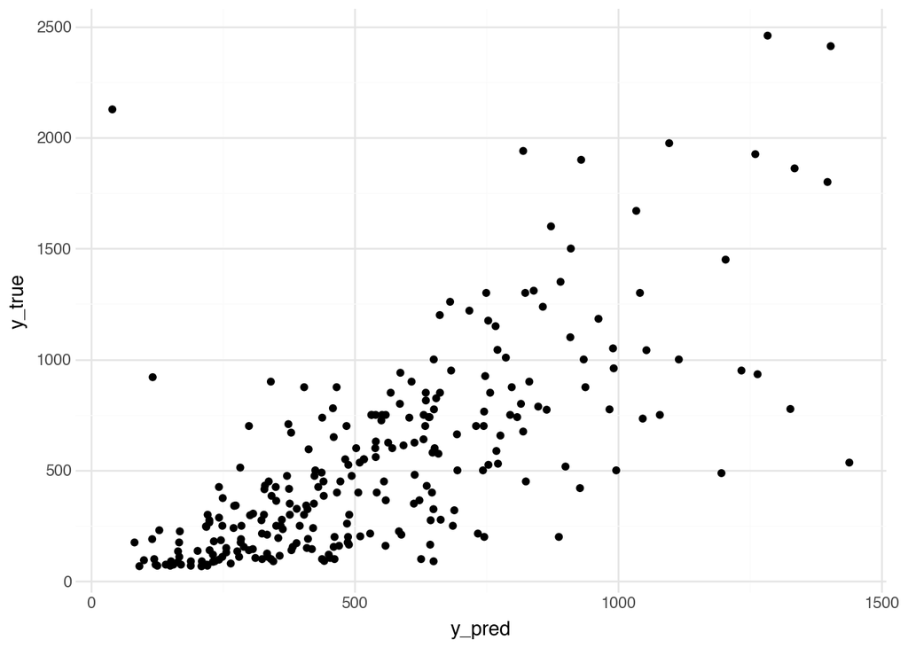

```python
import plotnine as p9
y_pred = elastic_pipeline_best.predict(X)
y_true = y.values
plot_df = pd.DataFrame({"y_pred": y_pred, "y_true": y_true})
(
p9.ggplot(plot_df, p9.aes(x="y_pred", y="y_true")) +
    p9.geom_point() +
    p9.theme_minimal()
)
```